# Bakery Sales Analysis

This notebook analyzes bakery transaction data to explore sales volume, revenue generation, and time-based trends using Python.

```python
import pandas as pd

df = pd.read_csv("Bakery.csv")
df.head()
```

|  | TransactionNo | Items | DateTime | Daypart | DayType | Quantity | Price |
| --- | --- | --- | --- | --- | --- | --- | --- |
| 0 | 1 | Bread | 30-10-2016 09:58 | Morning | Weekend | 5 | 35 |
| 1 | 2 | Scandinavian | 30-10-2016 10:05 | Morning | Weekend | 1 | 43 |
| 2 | 2 | Scandinavian | 30-10-2016 10:05 | Morning | Weekend | 1 | 43 |
| 3 | 3 | Hot chocolate | 30-10-2016 10:07 | Morning | Weekend | 4 | 97 |
| 4 | 3 | Jam | 30-10-2016 10:07 | Morning | Weekend | 3 | 96 |

```python
df.shape
```

```
(20507, 7)
```

```python
df.info()
```

```
<class 'pandas.core.frame.DataFrame'>
RangeIndex: 20507 entries, 0 to 20506
Data columns (total 7 columns):
 #   Column         Non-Null Count  Dtype
---  ------         --------------  -----
 0   TransactionNo  20507 non-null  int64
 1   Items          20507 non-null  object
 2   DateTime       20507 non-null  object
 3   Daypart        20507 non-null  object
 4   DayType        20507 non-null  object
 5   Quantity       20507 non-null  int64
 6   Price          20507 non-null  int64
dtypes: int64(3), object(4)
memory usage: 1.1+ MB
```

```python
df.describe()
```

|  | TransactionNo | Quantity | Price |
| --- | --- | --- | --- |
| count | 20507.000000 | 20507.000000 | 20507.000000 |
| mean | 4976.202370 | 2.998147 | 51.027454 |
| std | 2796.203001 | 1.415246 | 17.976061 |
| min | 1.000000 | 1.000000 | 31.000000 |
| 25% | 2552.000000 | 2.000000 | 39.000000 |
| 50% | 5137.000000 | 3.000000 | 43.000000 |
| 75% | 7357.000000 | 4.000000 | 57.000000 |
| max | 9684.000000 | 5.000000 | 99.000000 |

```python
df["Revenue"] = df["Quantity"] * df["Price"]
df.head()
```

|  | TransactionNo | Items | DateTime | Daypart | DayType | Quantity | Price | Revenue |
| --- | --- | --- | --- | --- | --- | --- | --- | --- |
| 0 | 1 | Bread | 30-10-2016 09:58 | Morning | Weekend | 5 | 35 | 175 |
| 1 | 2 | Scandinavian | 30-10-2016 10:05 | Morning | Weekend | 1 | 43 | 43 |
| 2 | 2 | Scandinavian | 30-10-2016 10:05 | Morning | Weekend | 1 | 43 | 43 |
| 3 | 3 | Hot chocolate | 30-10-2016 10:07 | Morning | Weekend | 4 | 97 | 388 |
| 4 | 3 | Jam | 30-10-2016 10:07 | Morning | Weekend | 3 | 96 | 288 |

```python
top_items = (
    df.groupby("Items")["Quantity"]
      .sum()
      .sort_values(ascending=False)
      .head(10)
)

top_items
```

```
Items
Coffee           16376
Bread             9959
Tea               4218
Cake              3044
Pastry            2617
Sandwich          2318
Medialuna         1820
Hot chocolate     1786
Cookies           1619
Muffin            1137
Name: Quantity, dtype: int64
```

```python
top_revenue_items = (
    df.groupby("Items")["Revenue"]
      .sum()
      .sort_values(ascending=False)
      .head(10)
)

top_revenue_items
```

```
Items
Coffee           704168
Bread            348565
Hot chocolate    173242
Tea              164502
Cake             149156
Pastry           141318
Cookies          116568
Alfajores        100556
Brownie           93541
Toast             92736
Name: Revenue, dtype: int64
```

```python
df.groupby("Daypart")["Revenue"].sum().sort_values(ascending=False)
```

```
Daypart
Afternoon    1793796
Morning      1253956
Evening        89719
Night           2496
Name: Revenue, dtype: int64
```

**Data Exploration Summary:**  
The dataset contains transactional bakery sales data with features such as date, item name, quantity sold, price, daypart, and day type. A review of the dataset shows no missing values across all columns. Summary statistics indicate stable pricing and a wide range of sales volumes across products.

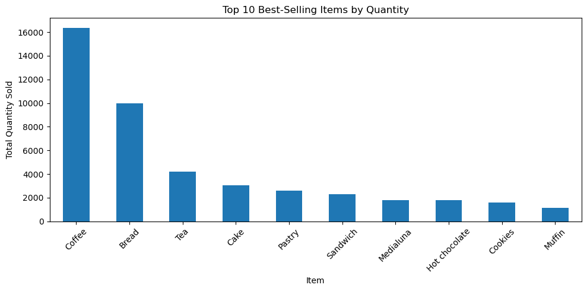

```python
import matplotlib.pyplot as plt

top_items.plot(kind="bar", figsize=(10,5))
plt.title("Top 10 Best-Selling Items by Quantity")
plt.xlabel("Item")
plt.ylabel("Total Quantity Sold")
plt.xticks(rotation=45)
plt.tight_layout()
plt.show()
```

**Insight:**  
This chart shows that a small number of bakery items account for a large share of total quantity sold, indicating demand concentration among top products.

```python
top_5_items = (
    df.groupby("Items")["Quantity"]
    .sum()
    .sort_values(ascending=False)
    .head(5)
)

top_5_items
```

```
Items
Coffee    16376
Bread      9959
Tea        4218
Cake       3044
Pastry     2617
Name: Quantity, dtype: int64
```

**Sales Analysis:**  
The table above shows the top 5 best-selling products based on total quantity sold. The leading product represents the most popular item among customers and accounts for a significant portion of total sales volume.

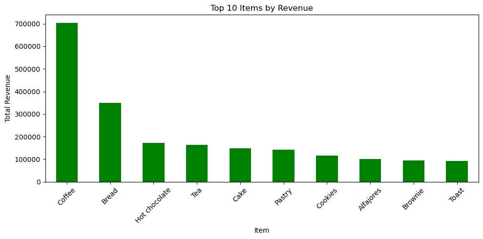

```python
df["Revenue"] = df["Quantity"] * df["Price"]

top_revenue_items = (
    df.groupby("Items")["Revenue"]
    .sum()
    .sort_values(ascending=False)
    .head(10)
)

top_revenue_items.plot(kind="bar", figsize=(10,5), color="green")
plt.title("Top 10 Items by Revenue")
plt.xlabel("Item")
plt.ylabel("Total Revenue")
plt.xticks(rotation=45)
plt.tight_layout()
plt.show()
```

**Insight:**  
This chart highlights the bakery items that generate the most revenue. Some items may sell less frequently but contribute more to total revenue due to higher prices or larger quantities per transaction. The product with the highest total revenue is the bakery’s strongest financial contributor, even if it is not the most frequently sold item.

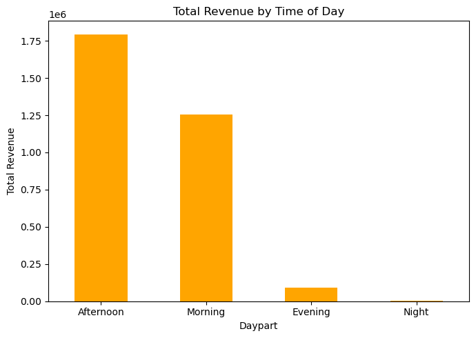

```python
daypart_revenue = (
    df.groupby("Daypart")["Revenue"]
    .sum()
    .sort_values(ascending=False)
)

daypart_revenue.plot(kind="bar", figsize=(7,5), color="orange")
plt.title("Total Revenue by Time of Day")
plt.xlabel("Daypart")
plt.ylabel("Total Revenue")
plt.xticks(rotation=0)
plt.tight_layout()
plt.show()
```

**Insight:**  
Revenue varies by time of day, with certain dayparts generating significantly more sales. This indicates peak business hours where staffing, inventory, and promotions can be optimized to maximize revenue.

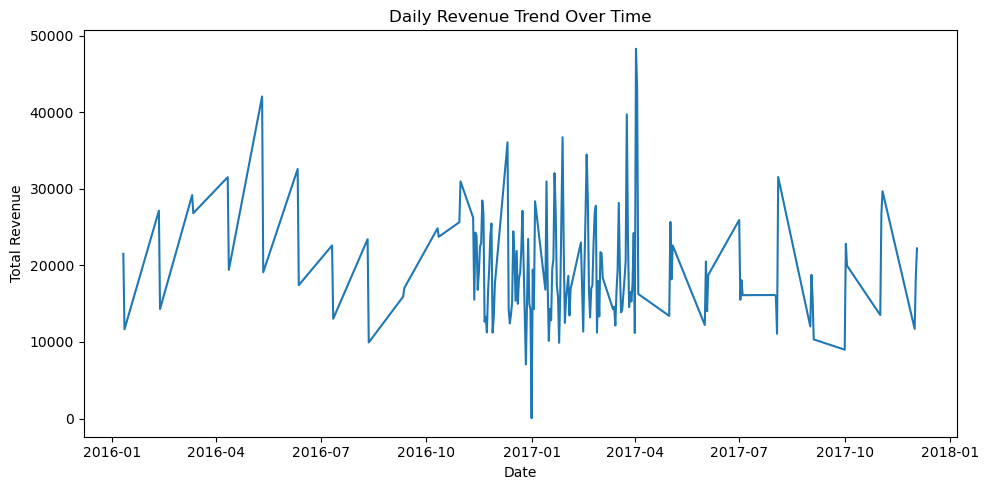

```python
df["Date"] = pd.to_datetime(df["DateTime"]).dt.date

daily_sales = df.groupby("Date")["Revenue"].sum()

plt.figure(figsize=(10,5))
plt.plot(daily_sales)
plt.title("Daily Revenue Trend Over Time")
plt.xlabel("Date")
plt.ylabel("Total Revenue")
plt.tight_layout()
plt.show()
```

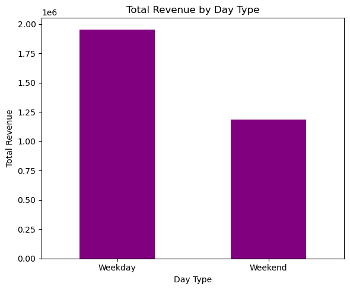

```python
daytype_revenue = (
    df.groupby("DayType")["Revenue"]
    .sum()
)

daytype_revenue.plot(kind="bar", figsize=(6,5), color="purple")
plt.title("Total Revenue by Day Type")
plt.xlabel("Day Type")
plt.ylabel("Total Revenue")
plt.xticks(rotation=0)
plt.tight_layout()
plt.show()
```

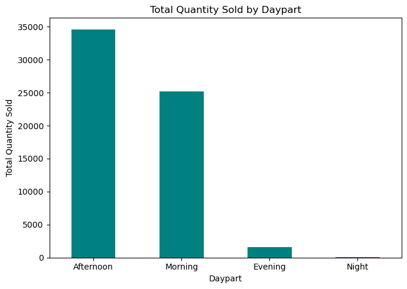

```python
daypart_quantity = (
    df.groupby("Daypart")["Quantity"]
    .sum()
    .sort_values(ascending=False)
)

daypart_quantity.plot(
    kind="bar",
    figsize=(7,5),
    color="teal"
)

plt.title("Total Quantity Sold by Daypart")
plt.xlabel("Daypart")
plt.ylabel("Total Quantity Sold")
plt.xticks(rotation=0)
plt.tight_layout()
plt.show()
```

**Insight:**  
The chart highlights which times of day drive the highest sales volume. Higher quantities during specific dayparts (such as Morning or Afternoon) indicate peak operational periods where staffing and inventory levels should be optimized.

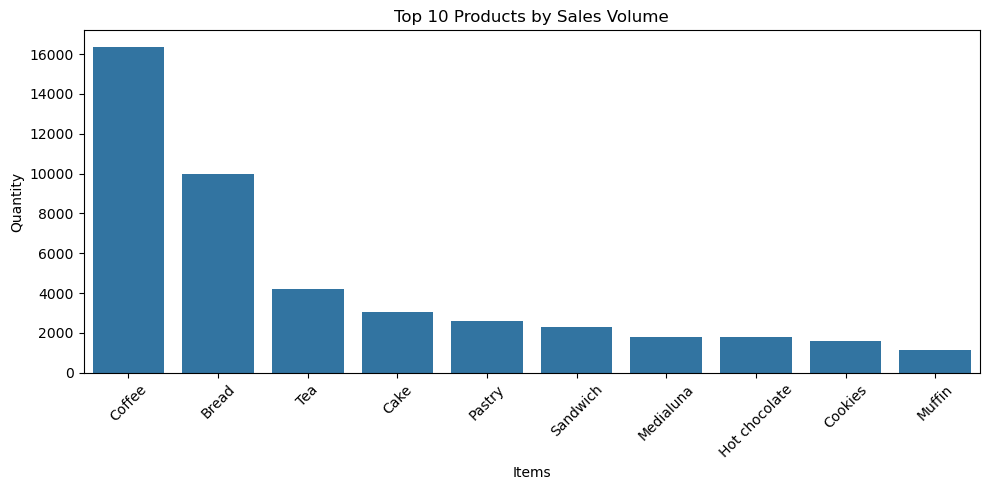

```python
import seaborn as sns

top_10_qty = (
    df.groupby("Items")["Quantity"]
    .sum()
    .sort_values(ascending=False)
    .head(10)
    .reset_index()
)

plt.figure(figsize=(10,5))
sns.barplot(data=top_10_qty, x="Items", y="Quantity")
plt.title("Top 10 Products by Sales Volume")
plt.xticks(rotation=45)
plt.tight_layout()
plt.show()
```

**Product Sales Visualization:**  
This Seaborn bar chart highlights the top 10 products based on sales volume. A small group of products accounts for a large share of total sales, indicating strong customer preferences.

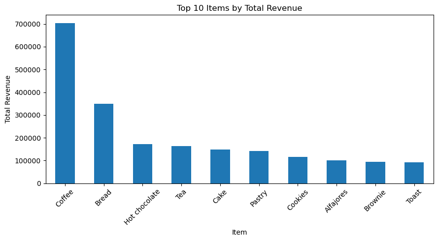

```python
item_revenue = (
    df.assign(TotalRevenue=df["Quantity"] * df["Price"])
      .groupby("Items")["TotalRevenue"]
      .sum()
      .sort_values(ascending=False)
      .head(10)
)

item_revenue.plot(
    kind="bar",
    figsize=(9,5)
)

plt.title("Top 10 Items by Total Revenue")
plt.xlabel("Item")
plt.ylabel("Total Revenue")
plt.xticks(rotation=45)
plt.tight_layout()
plt.show()
```

**Insight:**  
This chart shows which bakery items generate the highest total revenue. While some items may sell frequently, higher-priced products can contribute more significantly to overall revenue, highlighting opportunities for profit optimization.

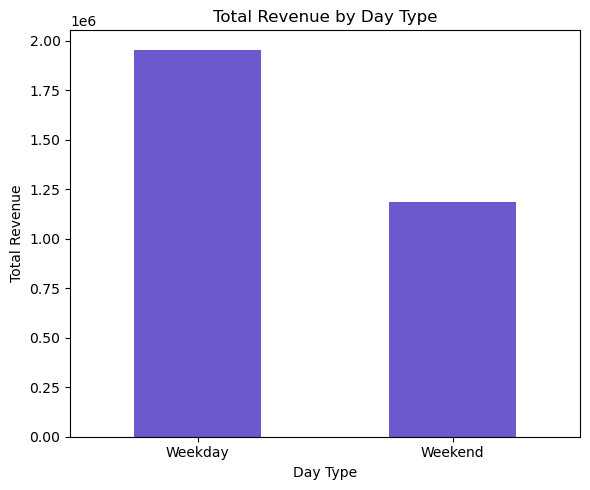

```python
daytype_revenue = (
    df.groupby("DayType")["Revenue"]
    .sum()
)

daytype_revenue.plot(
    kind="bar",
    figsize=(6,5),
    color="slateblue"
)

plt.title("Total Revenue by Day Type")
plt.xlabel("Day Type")
plt.ylabel("Total Revenue")
plt.xticks(rotation=0)
plt.tight_layout()
plt.show()
```

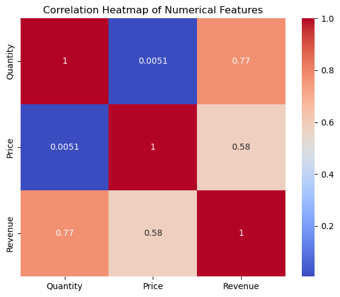

```python
numeric_df = df[["Quantity", "Price", "Revenue"]]

plt.figure(figsize=(6,5))
sns.heatmap(numeric_df.corr(), annot=True, cmap="coolwarm")
plt.title("Correlation Heatmap of Numerical Features")
plt.tight_layout()
plt.show()
```

**Correlation Analysis:**  
The heatmap shows the relationships between numerical variables. Revenue has a strong positive correlation with quantity sold, while price shows weaker correlation, indicating that sales volume is the primary driver of revenue.